# Legalization & Cannabis Use

Stats 115 Final Project

Charles Gao  
Andrew Hwang  
Jason Huffstutter  
Andrew Hahm

## Our Research Question

- Was early state-level marijuana legalization in 2012 (Washington, Colorado) and 2014 (Alaska, Oregon) associated with higher marijuana-use rates among ages 18–25, beyond the broader national trend?

## Background & Motivation

Why should we care about this topic?

- Marijuana legalization is a policy issue in the United States that goes beyond red/blue politics, as it reflects family dynamics, community experiences, and personal values.
- A key concern is whether legalization is associated with significantly higher marijuana use, especially among young adults.

Who will these results help in the future?

- Policymakers can use these results to better understand how marijuana regulation can affect younger demographics.
- Public health groups and schools can use this information to better educate and improve prevention efforts.
- Individuals can gain knowledge to create more informed opinions.

## Dataset Overview

```
Dimensions: 867 observations × 53 variables
```

```
Years: 2002 - 2018
```

```
States: 51 (includes Washington D.C.)
```

**Key Variables:**

- **Demographics**: State, Year, Population by age group
- **Substances**: Marijuana, Tobacco, Alcohol, Cocaine
- **Metrics**: Totals (counts) and Rates (per 1000 people)
- **Time frames**: Past month, past year usage

**Age Groups:**

- 12-17 (adolescents)
- 18-25 (young adults)
- 26+ (adults)

## Marijuana Trends by Age

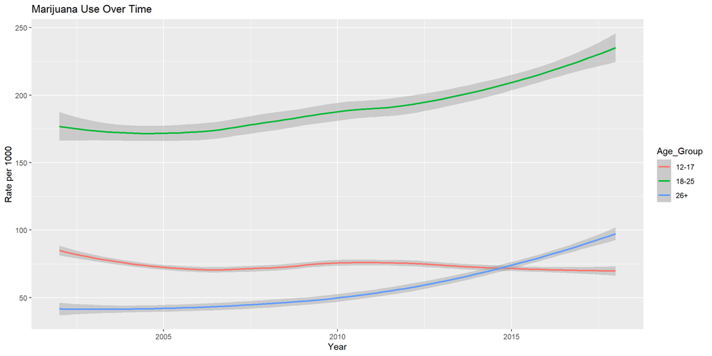

The 18–25 age group shows an increasing rate over time and remains significantly higher than the other two age groups.

## States Ranked by Marijuana Use (2018)

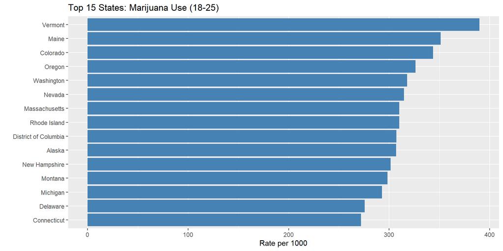

## Correlation Matrix

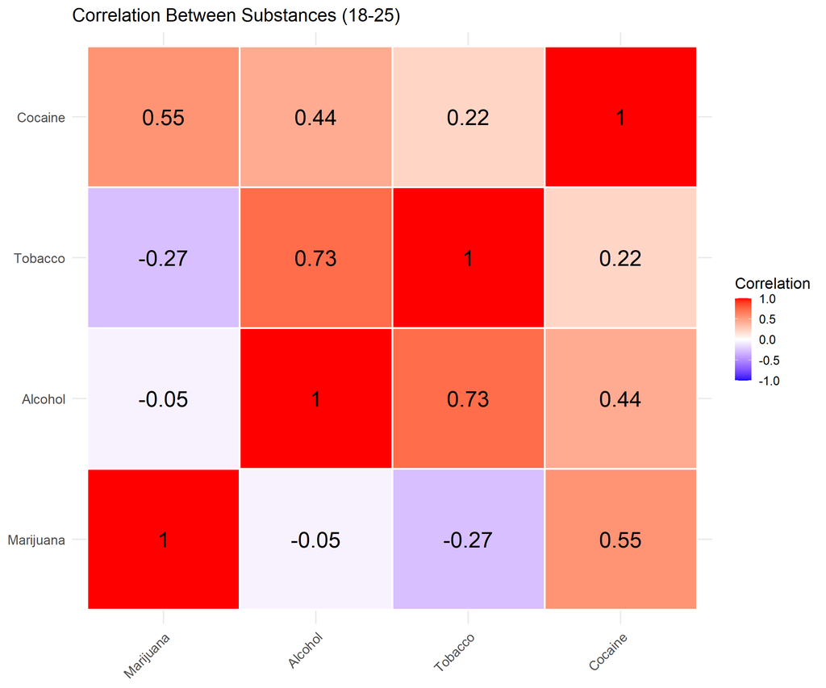

**Two distinct camps:** Cocaine & Marijuana users (r = 0.55) vs Alcohol & Tobacco users (r = 0.73)

**Key insight:** Marijuana and Tobacco negatively correlated (r = -0.27) - both are smoking activities, individuals choose one over the other

## All Substance Trends

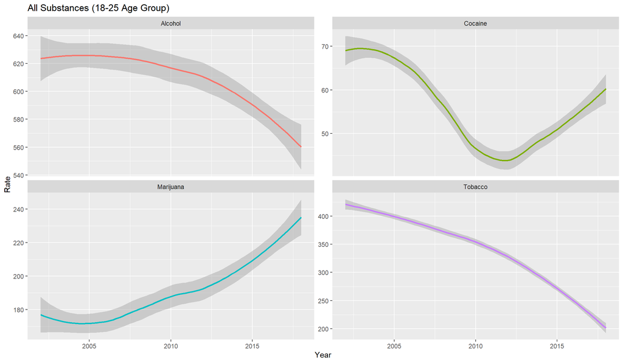

## Revisiting our Question

- Was early state-level marijuana legalization in 2012 (Washington, Colorado) and 2014 (Alaska, Oregon) associated with higher marijuana-use rates among ages 18–25, beyond the broader national trend?

Our exploratory analysis suggested that marijuana use among **18–25-year-olds** rose in the years following legalization. We then asked whether early-adopter states experienced an additional post-legalization increase relative to the broader national pattern, or whether usage was simply rising along with the national trajectory.

## Legalization Timeline

**Early Adopter States:**

- **2012**: Washington & Colorado legalized recreational marijuana
- **2014**: Alaska & Oregon legalized recreational marijuana

**Our Analysis:**

Compare marijuana usage rates in these 4 early-adopter states vs. all other states to identify:

1. Pre-legalization baseline differences
2. Post-legalization divergence (if any)
3. Whether early-adopter states showed larger post-legalization increases than other states

## Marijuana Rates: Early Adopters vs Others

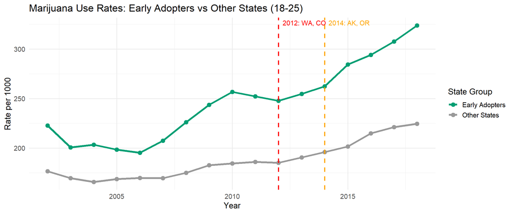

## Pre vs Post Legalization Trends

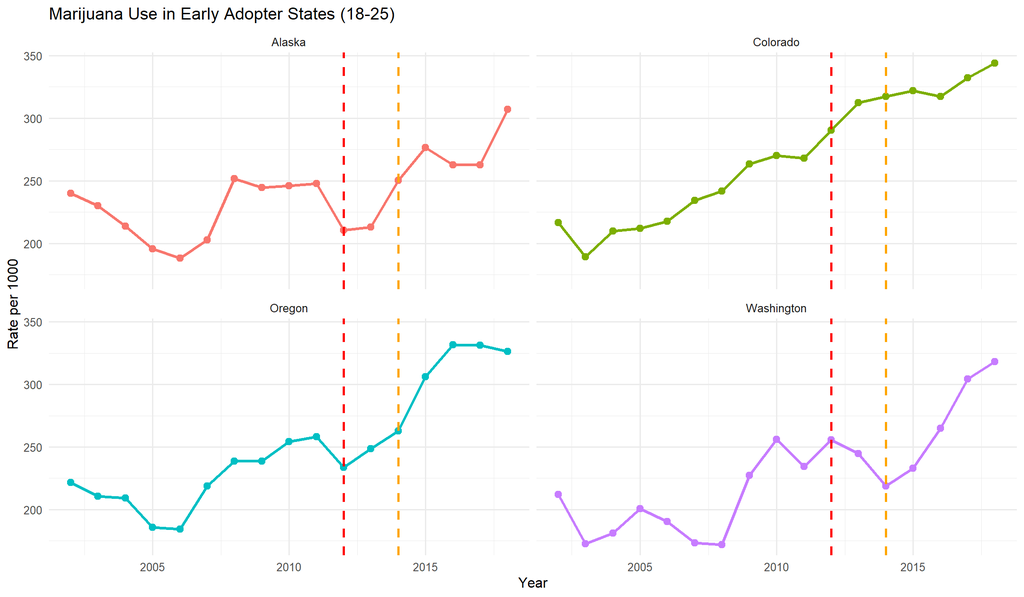

## Findings

```
Pre-2012 Average Rates (per 1000):
```

```
  Early Adopters: 220.58
```

```
  Other States: 174.73
```

```
  Difference: 45.85
```

```
Post-2014 Average Rates (per 1000):
```

```
  Early Adopters: 294.44
```

```
  Other States: 211.56
```

```
  Difference: 82.88
```

```
Change from Pre-2012 to Post-2014:
```

```
  Early Adopters: + 73.86 ( 33.5 % increase)
```

```
  Other States: + 36.83 ( 21.1 % increase)
```

*Note: This analysis uses all pre-2012 vs all post-2014 data for comprehensive coverage.*

**Interpretation:**

- Larger increases in early-adopter states are consistent with a positive post-legalization association, but do **not establish causality by themselves**
- Similar increases across groups would be more consistent with a broader national trend
- Baseline differences suggest early-adopter states may already have had stronger underlying demand or different pre-existing preferences

## Statistical Testing: Did Legalization Matter?

**Modeling Strategy:**

Because legalization occurred at different times across the treated states, we define a **state-specific post-legalization indicator**:

- $Post_{it}=1$ if state $i$ is in a legalized period in year $t$
- $Post_{it}=0$ otherwise

This means $Post_{it}$ already represents the treatment exposure for early-adopter states after legalization. It is effectively a **treated × post** indicator, so we do **not** need a separate interaction term such as $EarlyAdopter_i \times Post_t$ in this model.

## Two-Sample t-test on Growth Rates

Let’s first run a simple t-test:

$$H_0:\ \mu_{\text{Early growth}} = \mu_{\text{Other growth}}$$

$$H_1:\ \mu_{\text{Early growth}} > \mu_{\text{Other growth}}$$

```
Two-Sample t-test: Early Adopters vs Other States
```

```
Mean growth Early Adopters: 34.9
```

```
Mean growth Other States: 23.13
```

```
t-statistic: 0.85
```

```
p-value: 0.2249
```

```
Conclusion: No statistically significant difference in average growth was detected
```

**Note:** This t-test uses 2010-2011 (pre) vs 2015-2016 (post) for a clean comparison around the legalization dates.

## Proposed Model

$$Rate_{it} \sim \text{Normal}(\mu_{it}, \sigma)$$

$$\mu_{it} = \alpha_i + \lambda_t + \beta Post_{it}$$

**Where:**

- $Rate_{it}$ is the marijuana-use rate for state $i$ in year $t$
- $\alpha_i$ is the state-specific baseline level
- $\lambda_t$ is the year-specific effect shared by all states
- $Post_{it}$ is a state-specific post-legalization indicator

**Why use year effects instead of a linear year trend?**

A single linear time term assumes marijuana-use rates changed at a constant national rate over time. Using year effects is more flexible: it allows each year to have its own national shift, which better captures non-linear changes in marijuana use over the sample period.

## Model Interpretation

**Key Parameter:** $β$ ($Post_{it}$)

If $β > 0$, then marijuana-use rates were higher in treated states during their post-legalization years, after accounting for:

- baseline differences across states through $α_i$
- nationwide year-to-year shocks through $λ_t$

Because $Post_{it}$ is defined separately for each state based on its own legalization year, it already serves as the treatment indicator for “treated state after legalization.”

**Parameter meanings:**

- $α_i$: state-specific baseline marijuana-use level
- $λ_t$: year-specific national effect
- $β$: additional post-legalization shift in treated states

## MCMC Trace

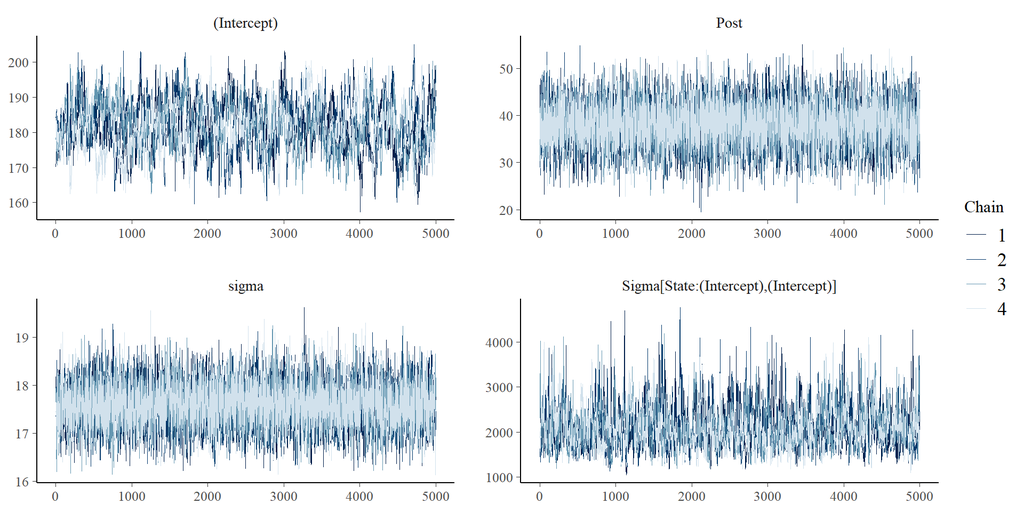

The traceplots show good mixing across chains

## MCMC Density Overlay

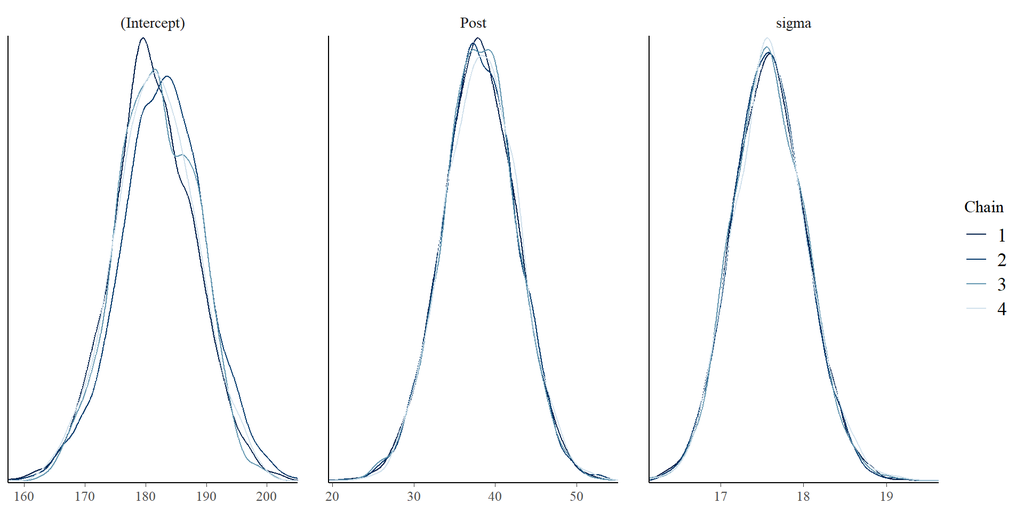

Density overlays are quite consistent across chains. Intercept chains showed slight variation, but overall the posterior simulation converged well and the MCMC samples are reliable for inference.

## Posterior Predictive Check

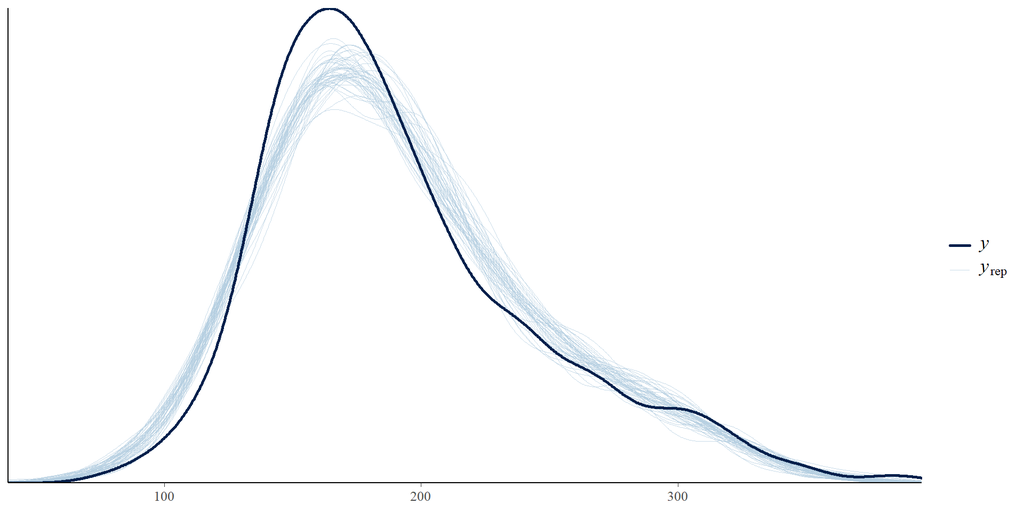

Our simulated data from the posterior match the observed distribution and trend quite well. The model captures the main structure of the marijuana-use data reasonably well.

## Bayesian Analysis Results

**Posterior Summary:**

- $95\%$ credible interval for $β$ ($Post_{it}$): $[29.02,\ 46.99]$
- $P(β > 0 \mid data) = 1.00$

**Interpretation:** After accounting for state-level baseline differences and year-specific national effects, the estimated post-legalization coefficient remains clearly positive. Under this model, post-legalization years in treated states were associated with an additional increase of about 29 to 47 rate points in marijuana-use rates among ages 18–25. This estimate reflects a post-legalization level shift rather than a different slope over time.

## Comparing the Approaches

**Descriptive Analysis:**

- Early-adopter states showed larger increases in marijuana-use rates than other states
- However, these states also had higher baseline usage before legalization

**Frequentist Test:**

- The two-sample t-test found higher average growth in early-adopter states
- However, the difference was not statistically significant

**Bayesian Model:**

- The model controls for state-level baseline differences and year-specific national effects
- The post-legalization indicator $Post_{it}$ remained strongly positive: $95\%$ credible interval $[29.02,\ 46.99]$

## Where could we go from here?

- We could study other factors like dispensary access, advertising, and explore different demographics outside of just age.
- We could increase the timeframe we are looking at to study long term effects, and potentially combine our findings with other datasets that include information on post 2018 legalization.
- We could collect more detailed data, such as county-level, instead of only state-level averages.
- We could explore the link between marijuana and other substances, studying more how their rates are related.

**Thank you**